# Análise dos dados de doenças do coração

## Tratamento dos dados

Para iniciar, usaremos as seguintes bibliotecas do Python:

```python
import pandas as pd
import os
import matplotlib.pyplot as plt
import seaborn as sns
```

Para a análise dos dados clínicos dos pacientes utilizaremos a base de dados disponibilizadas em aulas.

Primeiramente, vamos ler os dados do nosso repositório:

```python
df = pd.read_excel('heart_disease.xlsx', 'data')

df.head(5)
```

|  | HeartDisease | BMI | Smoking | AlcoholDrinking | Stroke | PhysicalHealth | MentalHealth | DiffWalking | Sex | AgeCategory | Race | Diabetic | PhysicalActivity | GenHealth | SleepTime | Asthma | KidneyDisease | SkinCancer |
| --- | --- | --- | --- | --- | --- | --- | --- | --- | --- | --- | --- | --- | --- | --- | --- | --- | --- | --- |
| 0 | No | 16.60 | Yes | No | No | 3 | 30 | No | Female | 55-59 | White | Yes | Yes | Very good | 5 | Yes | No | Yes |
| 1 | No | 20.34 | No | No | Yes | 0 | 0 | No | Female | 80 or older | White | No | Yes | Very good | 7 | No | No | No |
| 2 | No | 26.58 | Yes | No | No | 20 | 30 | No | Male | 65-69 | White | Yes | Yes | Fair | 8 | Yes | No | No |
| 3 | No | 24.21 | No | No | No | 0 | 0 | No | Female | 75-79 | White | No | No | Good | 6 | No | No | Yes |
| 4 | No | 23.71 | No | No | No | 28 | 0 | Yes | Female | 40-44 | White | No | Yes | Very good | 8 | No | No | No |

Como podemos ver, temos algumas características relacionadas a cada paciente. Através desses dados tentaremos traçar algumas variáveis explicativas para doença no coração.

## Estatística descritiva básica

Para facilitar a elaboração dos dados, faremos a função "get_plot()" para plotar os gráficos de acordo com as variáveis desejadas.

```python
def get_plot(variaveis, k):

        df_plot = df.groupby([variaveis]).mean().reset_index()
        df_plot = df_plot.melt(id_vars=variaveis,
                               value_vars=["BMI", "PhysicalHealth", "MentalHealth", "SleepTime"])
        sns.barplot(data = df_plot, x="variable", y="value", hue=variaveis)
        plt.rcParams['figure.dpi']= k
```

Nossos dados possuem apenas 4 variáveis quantitativas e 14 classificatórias. Por conta disso, travaremos as variáveis quantitativas e veremos como se comportam quando alteramos as variáveis de classificação.

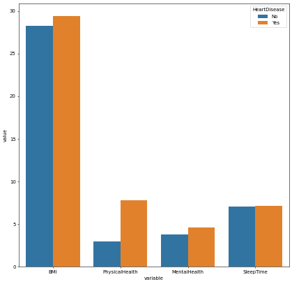

```python
get_plot('HeartDisease', 50)
```

No caso acima, podemos perceber que pessoas com problemas no coração possuem um indicie de gordura maior, estão a mais dias com problemas de saúde e problemas psicológicos. Já o tempo de sono é equivalente.

Agora, faremos o mesmo processo para quem consome bebidas alcoólicas.

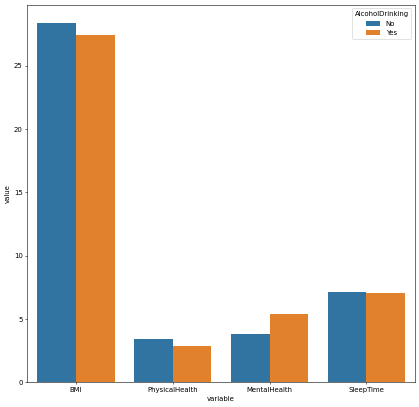

```python
get_plot('AlcoholDrinking', 50)
```

Como podemos analisar no gráfico acima para os pacientes consumidores de bebidas alcoólicas temos um menor índice de gordura, menos dias com problemas físicos, mas um número maior de dias com problemas psicológicos.

Agora, utilizando a mesma função para idade.

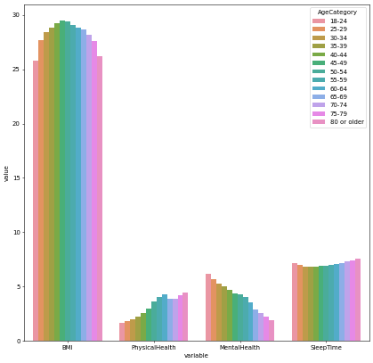

```python
get_plot('AgeCategory', 50)
```

Também podemos ver diferentes resultados dependendo da idade do paciente.

## Elaborando histogramas

Para facilitar a analise, novamente faremos uma função para plotar alguns histogramas.

```python
def get_hist(variavel, bins):
    plt.title(f'{variavel}')
    plt.xlabel(f'{variavel}')
    plt.ylabel('Frequência Absoluta')
    plt.hist(df[f'{variavel}'], bins, rwidth=0.9)
    plt.xticks(rotation=90)
    plt.show()
```

Com essa função podemos escolher as distribuições de frequência das "variáveis" e também controlar o número de barras do gráfico com "bins".

Agora faremos o histograma da variável "BMI", que está relacionada com gordura corporal

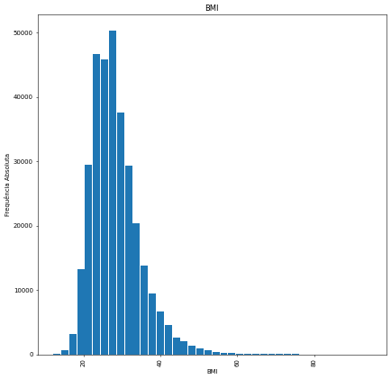

```python
get_hist("BMI", 40)
```

Agora faremos o mesmo para a variável "MentalHealth"

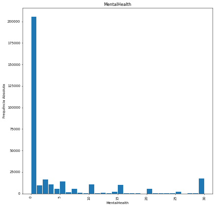

```python
get_hist("MentalHealth", 30)
```

Agora, para as categorias de idade.

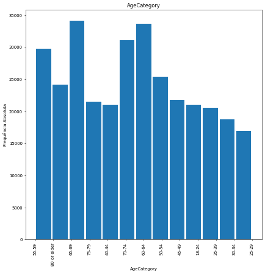

```python
get_hist("AgeCategory", 13)
```

## Correlação

Faremos a análise das correlações das variáveis quantitativas

```python
df.corr()
```

|  | BMI | PhysicalHealth | MentalHealth | SleepTime |
| --- | --- | --- | --- | --- |
| BMI | 1.000000 | 0.109788 | 0.064131 | -0.051822 |
| PhysicalHealth | 0.109788 | 1.000000 | 0.287987 | -0.061387 |
| MentalHealth | 0.064131 | 0.287987 | 1.000000 | -0.119717 |
| SleepTime | -0.051822 | -0.061387 | -0.119717 | 1.000000 |

Para facilitar a análise, faremos também "heatmap" com base nas correlações acima

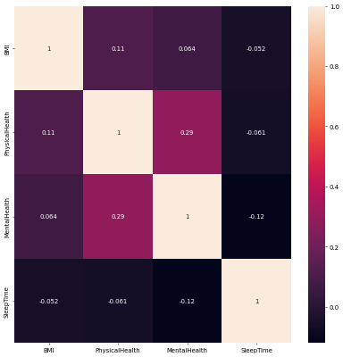

```python
sns.heatmap(df.corr(), annot=True)
```

Incluindo outras variáveis mais interessantas com a base "data_model".

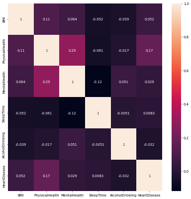

```python
sns.heatmap(data_model[["BMI", "PhysicalHealth", "MentalHealth", "SleepTime", "AlcoholDrinking","HeartDisease"]].corr(), annot=True)
```

# Modelagem

Para a análise faremos dois modelos, um de Regressão logistica e outro Support vector machine, utilizando o método Gradiente Descendente Estocástico - SGD.

Bibliotecas utilizadas:

```python
import pandas as pd
import numpy as np
from sklearn.model_selection import train_test_split
from sklearn import metrics
from sklearn.linear_model import SGDClassifier
import matplotlib.pyplot as plt
```

```python
Tratando os dados e criando dummies
```

```python
# criando dummies
data_model = pd.DataFrame({"HeartDisease": np.where(df["HeartDisease"] == "Yes", 1, 0),
                           "Smoking": np.where(df["Smoking"] == "Yes", 1, 0),
                           "AlcoholDrinking": np.where(df["AlcoholDrinking"] == "Yes", 1, 0),
                           "Stroke": np.where(df["Stroke"] == "Yes", 1, 0),
                           "DiffWalking": np.where(df["DiffWalking"] == "Yes", 1, 0),
                           "Sex": np.where(df["Sex"] == "Yes", 1, 0),
                           "PhysicalActivity": np.where(df["PhysicalActivity"] == "Yes", 1, 0),
                           "KidneyDisease": np.where(df["KidneyDisease"] == "Yes", 1, 0),
                           "SkinCancer": np.where(df["SkinCancer"] == "Yes", 1, 0),
                           "Asthma": np.where(df["Asthma"] == "Yes", 1, 0)})
```

```python
# dummies numéricas
data_model["BMI"] = df["BMI"]
data_model["PhysicalHealth"] = df["PhysicalHealth"]
data_model["MentalHealth"] = df["MentalHealth"]
data_model["SleepTime"] = df["SleepTime"]
```

```python
# inclundo as variaveis para dummies com mais de 2 categorias
data_model["AgeCategory"] = df["AgeCategory"]
data_model["Race"] = df["Race"]
data_model["Diabetic"] = df["Diabetic"]
data_model["GenHealth"] = df["GenHealth"]

#fazendo as ultimas dummies
data_model = pd.get_dummies(data_model)
```

Determinando variaveis explicatiavas e variaveis dependentes.

```python
y = data_model.HeartDisease
X = data_model.drop("HeartDisease", axis=1)
```

Separando dados de teste e dados de treino com 30% e 70%, respectivamente.

```python
X_train, X_test, y_train, y_test = train_test_split(X, y, test_size=0.3)
```

```python
# SVM
svm_clf = SGDClassifier(max_iter=1000, tol=1e-3, random_state=1, loss="huber")
```

Criando o modelo de Regressão Logistica com GDS

```python
log_clf = SGDClassifier(max_iter=1000, tol=1e-3, random_state=1, loss="log_loss")
```

Ajustando os modelos:

```python
svm_clf.fit(X_train, y_train)
log_clf.fit(X_train, y_train)
```

```
SGDClassifier(loss='log_loss', random_state=1)
```

```python
y_pred = log_clf.predict(X_test)
print("Accuracy:",metrics.accuracy_score(y_test, y_pred))
```

```
Accuracy: 0.9156755855283044
```

```python
y_pred = svm_clf.predict(X_test)
print("Accuracy:",metrics.accuracy_score(y_test, y_pred))
```

```
Accuracy: 0.9148104524750101
```

```python
Curva ROC, GINI, AUROC:
```

```python
## Plotado os gráficos
#para SVM
y_pred_svm = svm_clf.decision_function(X_test)
fpr_svm, tpr_svm, _ = metrics.roc_curve(y_test, y_pred_svm)
auc_svm = round(metrics.roc_auc_score(y_test, y_pred_svm), 4)
# para regressao logistica
y_pred_log = log_clf.predict_proba(X_test)[:, 1]
fpr_log, tpr_log, _ = metrics.roc_curve(y_test, y_pred_log)
auc_log = round(metrics.roc_auc_score(y_test, y_pred_log), 4)
```

```python
# Gini
gini_svm = round(2*auc_svm - 1, 4)
gini_log = round(2*auc_log - 1, 4)
```

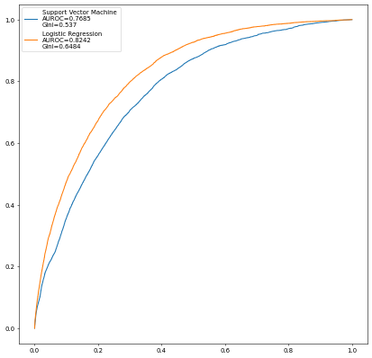

```python
plt.plot(fpr_svm,tpr_svm,label="Support Vector Machine \nAUROC="+str(auc_svm) + "\nGini=" + str(gini_svm))
plt.plot(fpr_log,tpr_log,label="Logistic Regression \nAUROC="+str(auc_log) + "\nGini=" + str(gini_log))
plt.legend()
plt.show()
```

Como podemos ver acima, o modelo de Regressão logistica superou o SVM já que possui maior GINI e menor número de falso positivo em comparação com positivo positivo.

## Variáveis

```python
Analisando as variáveis que influenciam no modelo positivamente e negativamente
```

```python
# Variaveis que influenciam

coef_svm = pd.concat([pd.DataFrame(X_train.columns),pd.DataFrame(np.transpose(svm_clf.coef_))], axis = 1)
coef_log = pd.concat([pd.DataFrame(X_train.columns),pd.DataFrame(np.transpose(log_clf.coef_))], axis = 1)

coef_svm.columns = ["Coef", "Values"]
coef_log.columns = ["Coef", "Values"]

last3_svm = coef_svm.sort_values(by="Values").head(3)
last3_log = coef_log.sort_values(by="Values").head(3)

top3_svm = coef_svm.sort_values(by="Values").tail(3)
top3_log = coef_log.sort_values(by="Values").tail(3)
```

Influenciam positivamente:

```python
# infulenciam positivamente
print(top3_svm)
print(top3_log)
```

```
              Coef    Values
6    KidneyDisease  0.028706
2           Stroke  0.053801
39  GenHealth_Poor  0.060496
                       Coef    Values
24        AgeCategory_75-79  1.350499
39           GenHealth_Poor  1.354913
25  AgeCategory_80 or older  1.549894
```

Influenciam negativamente:

```python
# influenciam negativamente
print(last3_svm)
print(last3_log)
```

```
                   Coef    Values
40  GenHealth_Very good -0.050426
36  GenHealth_Excellent -0.046140
38       GenHealth_Good -0.042517
                 Coef    Values
13  AgeCategory_18-24 -1.253647
14  AgeCategory_25-29 -1.072900
15  AgeCategory_30-34 -0.974303
```